# White Collar Crime

CRIM 100

## You remember this guy?

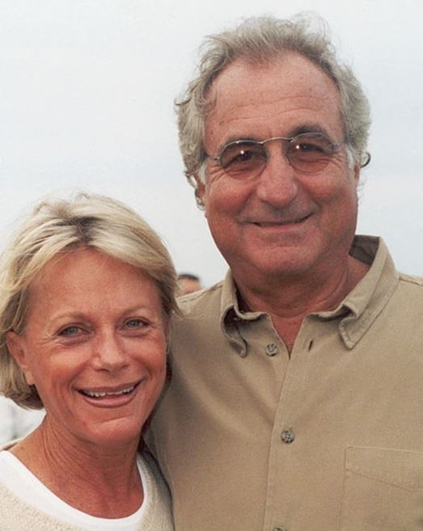

## Inside the Madoff Scandal: Chapter One

[video not shown]

## Inside the Madoff Scandal: Chapter Two

[video not shown]

## Definition

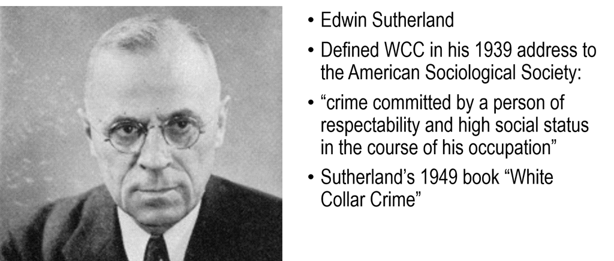

## Types of WCC

- Occupational crime
  - Refers to violations of the law in the course of practicing a legitimate occupation
- Organizational or corporate crime
  - WCC committed with the support and encouragement of a formal organization and intended, at least in part, tp advance the goals of the organization

## Features of WCC

- Offenders come from the upper classes
- Offenders have greater influence over the system (laws, regulations, law enforcement, etc.)
- Takes place in work environment
- Offences are complex and often involve breaking various types of laws and regulations
- Wider impact
- Corporate nature (legal personality) makes prosecution more complex

## Executive Disengagement

- Top figures are protected:
  - Subordinates believe its best not to inform
  - Not legally expected to have complete control

## Criminogenic Market Structure

The configuration and functioning of certain economic markets pushes participants into criminal behaviour.

## Large Scale of Corporations

- Freedom at the top
- Pressure at the bottom

## Corporate Accounting Scandals

- Artificially improve company’s financial standing
- Motivating factors:
  - Employee’s stock options
  - Performance bonus

# Content review

## Key Concepts

- WCC definition
- Occupational crime
- Organizational or corporate crime
- Features of WCC
- Executive Disengagement
- Criminogenic Market Structure
- Stock options
- Performance bonus